# Warm Up Python

### Columnas

Para ser practicos, normalmente modificamos los nombres de las columnas con el fin de quitar espacios en blanco, caracteres especiales, dejar los nombres en minuscula así que a continuacion realizaremos ese cambio.

```python
# Cambiar nombre de columnas a minusculas
titanic.rename(columns = lambda col: col.lower(),inplace=True)
```

```python
# Validar dataset
titanic.info()
```

```
<class 'pandas.core.frame.DataFrame'>
Int64Index: 712 entries, 0 to 890
Data columns (total 9 columns):
 #   Column    Non-Null Count  Dtype
---  ------    --------------  -----
 0   survived  712 non-null    int64
 1   pclass    712 non-null    int64
 2   sex       712 non-null    object
 3   age       712 non-null    float64
 4   sibsp     712 non-null    int64
 5   parch     712 non-null    int64
 6   ticket    712 non-null    object
 7   fare      712 non-null    float64
 8   embarked  712 non-null    object
dtypes: float64(2), int64(4), object(3)
memory usage: 55.6+ KB
```

```python
titanic.shape
```

```
(712, 9)
```

### Indices

```python
# Luego de eliminar los nulos, se debe de resetear los indices, como puedes ver aparecen de 0 a 890 todavia
# a persar de que tenemos 712 filas.
titanic.reset_index(drop=True,inplace=True)
titanic.info()
```

```
<class 'pandas.core.frame.DataFrame'>
RangeIndex: 712 entries, 0 to 711
Data columns (total 9 columns):
 #   Column    Non-Null Count  Dtype
---  ------    --------------  -----
 0   survived  712 non-null    int64
 1   pclass    712 non-null    int64
 2   sex       712 non-null    object
 3   age       712 non-null    float64
 4   sibsp     712 non-null    int64
 5   parch     712 non-null    int64
 6   ticket    712 non-null    object
 7   fare      712 non-null    float64
 8   embarked  712 non-null    object
dtypes: float64(2), int64(4), object(3)
memory usage: 50.2+ KB
```

### Agrupación

```python
titanic.groupby(['sex','survived']).size()
```

```
sex     survived
female  0            64
        1           195
male    0           360
        1            93
dtype: int64
```

```python
titanic.groupby(['sex','survived']).agg({'fare':'count','age':'mean'}).reset_index()
```

|  | sex | survived | fare | age |
| --- | --- | --- | --- | --- |
| 0 | female | 0 | 64 | 25.046875 |
| 1 | female | 1 | 195 | 28.630769 |
| 2 | male | 0 | 360 | 31.618056 |
| 3 | male | 1 | 93 | 27.276022 |

```python
# Validar los tickets duplicados
df_tickets = titanic.groupby('ticket').size().reset_index().rename(columns={0:'count'})
df_tickets.sort_values(by='count',ascending=False)
```

|  | ticket | count |
| --- | --- | --- |
| 273 | 347082 | 7 |
| 445 | CA 2144 | 6 |
| 207 | 3101295 | 6 |
| 277 | 347088 | 6 |
| 490 | S.O.C. 14879 | 5 |
| ... | ... | ... |
| 242 | 345763 | 1 |
| 241 | 345572 | 1 |
| 240 | 345364 | 1 |
| 239 | 343276 | 1 |
| 270 | 347078 | 1 |

541 rows × 2 columns

```python
titanic[titanic['ticket']=='347082']
```

|  | survived | pclass | sex | age | sibsp | parch | ticket | fare | embarked |
| --- | --- | --- | --- | --- | --- | --- | --- | --- | --- |
| 12 | 0 | 3 | male | 39.0 | 1 | 5 | 347082 | 31.275 | S |
| 93 | 0 | 3 | female | 2.0 | 4 | 2 | 347082 | 31.275 | S |
| 428 | 0 | 3 | female | 9.0 | 4 | 2 | 347082 | 31.275 | S |
| 429 | 0 | 3 | female | 11.0 | 4 | 2 | 347082 | 31.275 | S |
| 481 | 0 | 3 | female | 39.0 | 1 | 5 | 347082 | 31.275 | S |
| 649 | 0 | 3 | female | 6.0 | 4 | 2 | 347082 | 31.275 | S |
| 676 | 0 | 3 | male | 4.0 | 4 | 2 | 347082 | 31.275 | S |

```python
titanic[titanic['ticket']=='110413']
```

|  | survived | pclass | sex | age | sibsp | parch | ticket | fare | embarked |
| --- | --- | --- | --- | --- | --- | --- | --- | --- | --- |
| 210 | 0 | 1 | male | 52.0 | 1 | 1 | 110413 | 79.65 | S |
| 442 | 1 | 1 | female | 39.0 | 1 | 1 | 110413 | 79.65 | S |
| 462 | 1 | 1 | female | 18.0 | 0 | 2 | 110413 | 79.65 | S |

### Ordenando

```python
# Ordenar los cantidad de registros por tickets
df_tickets.sort_values(by=["count"],ascending=False,inplace=True)
df_tickets.head()
```

|  | ticket | count |
| --- | --- | --- |
| 273 | 347082 | 7 |
| 445 | CA 2144 | 6 |
| 207 | 3101295 | 6 |
| 277 | 347088 | 6 |
| 490 | S.O.C. 14879 | 5 |

```python
# Validemos un tiquete
titanic[titanic['ticket']=='347082']
```

|  | survived | pclass | sex | age | sibsp | parch | ticket | fare | embarked |
| --- | --- | --- | --- | --- | --- | --- | --- | --- | --- |
| 12 | 0 | 3 | male | 39.0 | 1 | 5 | 347082 | 31.275 | S |
| 93 | 0 | 3 | female | 2.0 | 4 | 2 | 347082 | 31.275 | S |
| 428 | 0 | 3 | female | 9.0 | 4 | 2 | 347082 | 31.275 | S |
| 429 | 0 | 3 | female | 11.0 | 4 | 2 | 347082 | 31.275 | S |
| 481 | 0 | 3 | female | 39.0 | 1 | 5 | 347082 | 31.275 | S |
| 649 | 0 | 3 | female | 6.0 | 4 | 2 | 347082 | 31.275 | S |
| 676 | 0 | 3 | male | 4.0 | 4 | 2 | 347082 | 31.275 | S |

### Uniendo datasets

Uno de las tareas que se realizan en preprocesamiento es enriquecer la información, crearemos una nueva columna llamada 'family' en esta realizaremos una marcación de 1 si el viaje fue familiar o viajaron solos.

```python
# Primero adicionaremos la columna 'count' de df_tickets a nuestro dataset titanic
titanic = titanic.merge(df_tickets,left_on='ticket',right_on='ticket',how='left')
titanic.shape
```

```
(712, 10)
```

```python
titanic.head()
```

|  | survived | pclass | sex | age | sibsp | parch | ticket | fare | embarked | count |
| --- | --- | --- | --- | --- | --- | --- | --- | --- | --- | --- |
| 0 | 0 | 3 | male | 22.0 | 1 | 0 | A/5 21171 | 7.2500 | S | 1 |
| 1 | 1 | 1 | female | 38.0 | 1 | 0 | PC 17599 | 71.2833 | C | 1 |
| 2 | 1 | 3 | female | 26.0 | 0 | 0 | STON/O2. 3101282 | 7.9250 | S | 1 |
| 3 | 1 | 1 | female | 35.0 | 1 | 0 | 113803 | 53.1000 | S | 2 |
| 4 | 0 | 3 | male | 35.0 | 0 | 0 | 373450 | 8.0500 | S | 1 |

### Enriquecer dataset

```python
titanic['family'] = [1 if count>1 else 0 for count in titanic['count']]
```

```python
titanic.head()
```

|  | survived | pclass | sex | age | sibsp | parch | ticket | fare | embarked | count | family |
| --- | --- | --- | --- | --- | --- | --- | --- | --- | --- | --- | --- |
| 0 | 0 | 3 | male | 22.0 | 1 | 0 | A/5 21171 | 7.2500 | S | 1 | 0 |
| 1 | 1 | 1 | female | 38.0 | 1 | 0 | PC 17599 | 71.2833 | C | 1 | 0 |
| 2 | 1 | 3 | female | 26.0 | 0 | 0 | STON/O2. 3101282 | 7.9250 | S | 1 | 0 |
| 3 | 1 | 1 | female | 35.0 | 1 | 0 | 113803 | 53.1000 | S | 2 | 1 |
| 4 | 0 | 3 | male | 35.0 | 0 | 0 | 373450 | 8.0500 | S | 1 | 0 |

### Limpliando Cadenas

```python
# Recuerdan las funciones? vamos a crear una funcion que nos servira para limpiar texto, en este caso el campo tickets
def limpiar_caracteres(cadena):
    import re
    patron = '[^A-Za-z0-9]+'
    return re.sub(patron, '', cadena)
```

```python
titanic['ticket'] = titanic['ticket'].apply(limpiar_caracteres)
titanic.head()
```

|  | survived | pclass | sex | age | sibsp | parch | ticket | fare | embarked | count | family |
| --- | --- | --- | --- | --- | --- | --- | --- | --- | --- | --- | --- |
| 0 | 0 | 3 | male | 22.0 | 1 | 0 | A521171 | 7.2500 | S | 1 | 0 |
| 1 | 1 | 1 | female | 38.0 | 1 | 0 | PC17599 | 71.2833 | C | 1 | 0 |
| 2 | 1 | 3 | female | 26.0 | 0 | 0 | STONO23101282 | 7.9250 | S | 1 | 0 |
| 3 | 1 | 1 | female | 35.0 | 1 | 0 | 113803 | 53.1000 | S | 2 | 1 |
| 4 | 0 | 3 | male | 35.0 | 0 | 0 | 373450 | 8.0500 | S | 1 | 0 |

```python
# Para continuar eliminaremos la columna ticket
titanic.drop('ticket',axis=1,inplace=True)
titanic.head()
```

|  | survived | pclass | sex | age | sibsp | parch | fare | embarked | count | family |
| --- | --- | --- | --- | --- | --- | --- | --- | --- | --- | --- |
| 0 | 0 | 3 | male | 22.0 | 1 | 0 | 7.2500 | S | 1 | 0 |
| 1 | 1 | 1 | female | 38.0 | 1 | 0 | 71.2833 | C | 1 | 0 |
| 2 | 1 | 3 | female | 26.0 | 0 | 0 | 7.9250 | S | 1 | 0 |
| 3 | 1 | 1 | female | 35.0 | 1 | 0 | 53.1000 | S | 2 | 1 |
| 4 | 0 | 3 | male | 35.0 | 0 | 0 | 8.0500 | S | 1 | 0 |

### Codificando variables categoricas

En ocasiones se requiere volver columnares nuestros datos categoricos, para esto usamos tambien un metodo de pandas llamado get_dummies.

```python
titanic['sexDummies'] = titanic['sex']
titanic = pd.get_dummies(titanic, columns = ['sexDummies'], prefix = ['D'])
titanic.head()
```

|  | survived | pclass | sex | age | sibsp | parch | fare | embarked | count | family | D_female | D_male |
| --- | --- | --- | --- | --- | --- | --- | --- | --- | --- | --- | --- | --- |
| 0 | 0 | 3 | male | 22.0 | 1 | 0 | 7.2500 | S | 1 | 0 | 0 | 1 |
| 1 | 1 | 1 | female | 38.0 | 1 | 0 | 71.2833 | C | 1 | 0 | 1 | 0 |
| 2 | 1 | 3 | female | 26.0 | 0 | 0 | 7.9250 | S | 1 | 0 | 1 | 0 |
| 3 | 1 | 1 | female | 35.0 | 1 | 0 | 53.1000 | S | 2 | 1 | 1 | 0 |
| 4 | 0 | 3 | male | 35.0 | 0 | 0 | 8.0500 | S | 1 | 0 | 0 | 1 |

Que hemos aprendido:

- Tratar Nulos
- Transformar columnas
- Enriquecer información en nuestro dataset adicionando columnas calculadas
- Hacer agregaciones
- Unir datasets.
- Limpiar texto con la ayuda de Regex
- Codificando variables categoricas

### Practica

- Agrupar el conjunto de datos por genero ('sex') y calcular el promedio de la edad ('age').
- Agrupar el conjunto de datos por la columna familia ('family') y contar la cantidad de registros por grupo.
- De las familias cuantos se sobrevivieron y cuantos no.

```python
# Agrupar el conjunto de datos por genero ('sex') y calcular el promedio de la edad ('age')
# Tu código
```

**Deberia de tener el siguiente resultado:**

[output not shown]

Doble-clic **Aqui** para la solución.

```python
# Agrupar el conjunto de datos por la columna familia ('family') y contar la cantidad de registros por grupo.
# Tu código
```

**Deberia de tener el siguiente resultado:**

[output not shown]

Doble-clic **Aqui** para la solución.

```python
# De las familias cuantos se sobrevivieron y cuantos no.
# Tu codigo
titanic.groupby(['family','survived']).size()
```

```
family  survived
0       0           293
        1           138
1       0           131
        1           150
dtype: int64
```

**Deberia de tener el siguiente resultado:**

[output not shown]

Doble-clic **Aqui** para la solución.

## Visualización:

Para apoyar el análisis descriptivo de los datos usamos la exploración de estos a través de gráficos que nos permiten conocer más la información que vamos a utilizar para nuestros modelos, para esta fase es muy util tener conocimiento de las librerias de Python que nos permiter generar estas visualizaciones como Matplotlib y Seaborn, Pandas tambien tiene unos métodos de visualización.

```python
import matplotlib.pyplot as plt
import seaborn as sns
%matplotlib inline

titanic.head()
```

|  | survived | pclass | sex | age | sibsp | parch | fare | embarked | count | family | D_female | D_male |
| --- | --- | --- | --- | --- | --- | --- | --- | --- | --- | --- | --- | --- |
| 0 | 0 | 3 | male | 22.0 | 1 | 0 | 7.2500 | S | 1 | 0 | 0 | 1 |
| 1 | 1 | 1 | female | 38.0 | 1 | 0 | 71.2833 | C | 1 | 0 | 1 | 0 |
| 2 | 1 | 3 | female | 26.0 | 0 | 0 | 7.9250 | S | 1 | 0 | 1 | 0 |
| 3 | 1 | 1 | female | 35.0 | 1 | 0 | 53.1000 | S | 2 | 1 | 1 | 0 |
| 4 | 0 | 3 | male | 35.0 | 0 | 0 | 8.0500 | S | 1 | 0 | 0 | 1 |

### Lineas

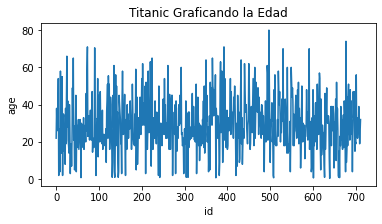

```python
# Empecemos con un grafico sencillo, al no colocar X se asume que x es cada uno de los registros.
plt.figure(figsize=(6,3))
plt.plot(titanic['age'])
plt.title('Titanic Graficando la Edad')
plt.xlabel('id')
plt.ylabel('age')
plt.show()
```

```python
?plt
```

### Histogramas

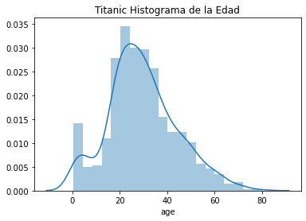

```python
plt.figure(figsize=(6,4))
sns.distplot(titanic['age'])
plt.title('Titanic Histograma de la Edad')
plt.show()
```

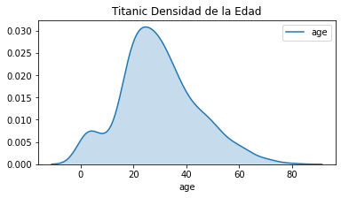

```python
# Si solo queremos la funcion de densidad
plt.figure(figsize=(6,3))
sns.kdeplot(titanic['age'],shade=True)
plt.title('Titanic Densidad de la Edad')
plt.xlabel('age');
```

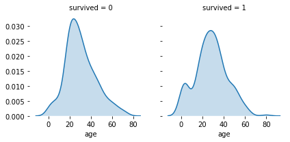

```python
g = sns.FacetGrid(titanic, col="survived", height=3)
g.map(sns.kdeplot, 'age', shade=True)
g.despine(left=True,bottom=True);
```

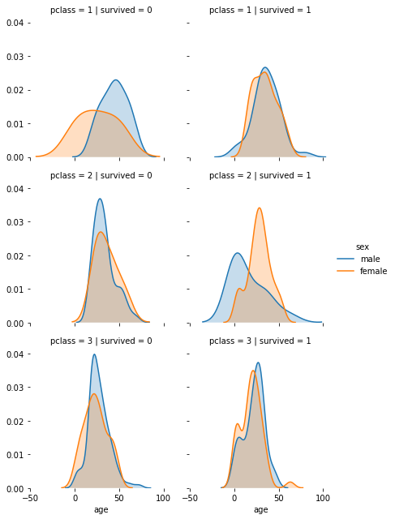

```python
g = sns.FacetGrid(titanic, col='survived', row='pclass', hue='sex', height=3)
g.map(sns.kdeplot, 'age', shade=True).add_legend()
g.despine(left=True, bottom=True)
plt.show()
```

### Boxplot

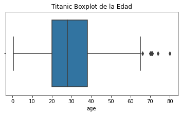

```python
plt.figure(figsize=(6,3))
sns.boxplot(titanic['age'])#,orient='v')
plt.title('Titanic Boxplot de la Edad')
plt.show()
```

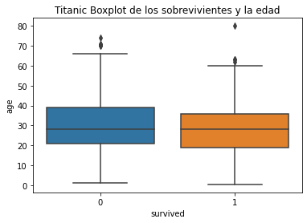

```python
plt.figure(figsize=(6,4))
sns.boxplot(x='survived',y='age',data=titanic)
plt.title('Titanic Boxplot de los sobrevivientes y la edad')
plt.show()
```

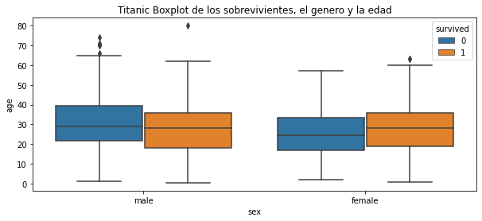

```python
plt.figure(figsize=(10,4))
sns.boxplot(x='sex',y='age',hue='survived',data=titanic)
plt.title('Titanic Boxplot de los sobrevivientes, el genero y la edad')
plt.show()
```

### Barras

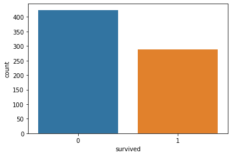

```python
plt.figure(figsize=(6, 4))
sns.countplot('survived',data=titanic)
plt.show()
```

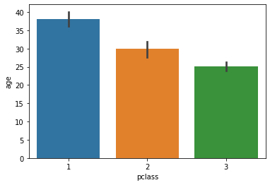

```python
plt.figure(figsize=(6, 4))
sns.barplot(y='age',x='pclass',data=titanic)
plt.show()
```

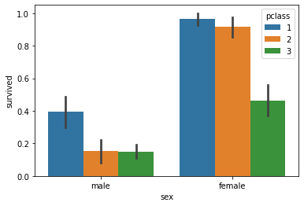

```python
plt.figure(figsize=(6, 4))
sns.barplot(y='survived',x='sex',hue='pclass',data=titanic)
plt.show()
```

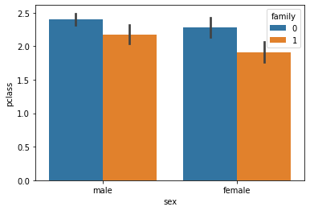

```python
plt.figure(figsize=(6, 4))
sns.barplot(y='pclass',x='sex',hue='family',data=titanic)
plt.show()
```

# Heatmap

```python
titanic.drop(['survived','family','D_female','D_male','count'],axis=1).corr()
```

|  | pclass | age | sibsp | parch | fare |
| --- | --- | --- | --- | --- | --- |
| pclass | 1.000000 | -0.365902 | 0.065187 | 0.023666 | -0.552893 |
| age | -0.365902 | 1.000000 | -0.307351 | -0.187896 | 0.093143 |
| sibsp | 0.065187 | -0.307351 | 1.000000 | 0.383338 | 0.139860 |
| parch | 0.023666 | -0.187896 | 0.383338 | 1.000000 | 0.206624 |
| fare | -0.552893 | 0.093143 | 0.139860 | 0.206624 | 1.000000 |

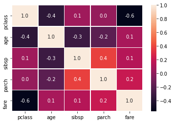

```python
plt.figure()
sns.heatmap(titanic.drop(['survived','family','D_female','D_male','count'],axis=1).corr(),annot=True, linewidth=0.5,fmt='.1f')
plt.show()
```

### Scatter Plot

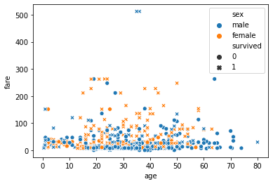

```python
plt.figure()
sns.scatterplot(x='age', y='fare', hue='sex', style='survived', data=titanic)
plt.show()
```

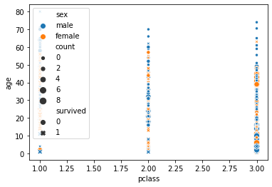

```python
plt.figure()
sns.scatterplot(x='pclass', y='age', hue='sex', style='survived',size='count', data=titanic)
plt.legend(loc='upper left')
plt.show()
```

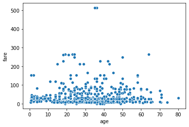

```python
plt.figure()
sns.scatterplot(x='age', y='fare',data=titanic)
plt.show()
```

```python
type(titanic.columns)
```

```
pandas.core.indexes.base.Index
```

```python
for  col in titanic.columns:
    print(col)
```

```
survived
pclass
sex
age
sibsp
parch
fare
embarked
count
family
D_female
D_male
```

```python
!pip install plotly
```

```python
import plotly.express as px
fig = px.scatter(titanic,x='age',y='fare', color='sex',size='count')
fig.show()
```

[interactive chart not shown]